# Project 2 - Analyzing Titanic Data

# by Dogan Askan

## Part 1 - First Glance

Metadata can be found at https://www.kaggle.com/c/titanic/data

```python
#Necessary libraries
import pandas as pd
import numpy as np
import seaborn as sns
import matplotlib.pyplot as plt
from scipy.stats import ttest_ind
from scipy.special import stdtr
import scipy.stats as stats
from scipy import stats
from statsmodels.stats.multicomp import (pairwise_tukeyhsd,
                                         MultiComparison)
```

After necessary libraries are loaded, an initial look can be taken to the data

```python
#load the data
filename = 'titanic_data.csv'
raw_titanic_df = pd.read_csv(filename)
raw_titanic_df.head() #the first glance
```

|  | PassengerId | Survived | Pclass | Name | Sex | Age | SibSp | Parch | Ticket | Fare | Cabin | Embarked |
| --- | --- | --- | --- | --- | --- | --- | --- | --- | --- | --- | --- | --- |
| 0 | 1 | 0 | 3 | Braund, Mr. Owen Harris | male | 22 | 1 | 0 | A/5 21171 | 7.2500 | NaN | S |
| 1 | 2 | 1 | 1 | Cumings, Mrs. John Bradley (Florence Briggs Th... | female | 38 | 1 | 0 | PC 17599 | 71.2833 | C85 | C |
| 2 | 3 | 1 | 3 | Heikkinen, Miss. Laina | female | 26 | 0 | 0 | STON/O2. 3101282 | 7.9250 | NaN | S |
| 3 | 4 | 1 | 1 | Futrelle, Mrs. Jacques Heath (Lily May Peel) | female | 35 | 1 | 0 | 113803 | 53.1000 | C123 | S |
| 4 | 5 | 0 | 3 | Allen, Mr. William Henry | male | 35 | 0 | 0 | 373450 | 8.0500 | NaN | S |

Below are the some descriptive statistics about the data.

```python
raw_titanic_df.groupby(['Pclass','Sex']).mean() #means grouped by "Age" and "Sex"
```

| Pclass | Sex | PassengerId | Survived | Age | SibSp | Parch | Fare |
| --- | --- | --- | --- | --- | --- | --- | --- |
| 1 | female | 469.212766 | 0.968085 | 34.611765 | 0.553191 | 0.457447 | 106.125798 |
|  | male | 455.729508 | 0.368852 | 41.281386 | 0.311475 | 0.278689 | 67.226127 |
| 2 | female | 443.105263 | 0.921053 | 28.722973 | 0.486842 | 0.605263 | 21.970121 |
|  | male | 447.962963 | 0.157407 | 30.740707 | 0.342593 | 0.222222 | 19.741782 |
| 3 | female | 399.729167 | 0.500000 | 21.750000 | 0.895833 | 0.798611 | 16.118810 |
|  | male | 455.515850 | 0.135447 | 26.507589 | 0.498559 | 0.224784 | 12.661633 |

```python
raw_titanic_df.describe() #Descriptive statiscits about the data
```

|  | PassengerId | Survived | Pclass | Age | SibSp | Parch | Fare |
| --- | --- | --- | --- | --- | --- | --- | --- |
| count | 891.000000 | 891.000000 | 891.000000 | 714.000000 | 891.000000 | 891.000000 | 891.000000 |
| mean | 446.000000 | 0.383838 | 2.308642 | 29.699118 | 0.523008 | 0.381594 | 32.204208 |
| std | 257.353842 | 0.486592 | 0.836071 | 14.526497 | 1.102743 | 0.806057 | 49.693429 |
| min | 1.000000 | 0.000000 | 1.000000 | 0.420000 | 0.000000 | 0.000000 | 0.000000 |
| 25% | 223.500000 | 0.000000 | 2.000000 | 20.125000 | 0.000000 | 0.000000 | 7.910400 |
| 50% | 446.000000 | 0.000000 | 3.000000 | 28.000000 | 0.000000 | 0.000000 | 14.454200 |
| 75% | 668.500000 | 1.000000 | 3.000000 | 38.000000 | 1.000000 | 0.000000 | 31.000000 |
| max | 891.000000 | 1.000000 | 3.000000 | 80.000000 | 8.000000 | 6.000000 | 512.329200 |

Since *Age* count is less than 891, there are some missing values.

```python
raw_titanic_df.info() #to check all missing values
```

```
<class 'pandas.core.frame.DataFrame'>
Int64Index: 891 entries, 0 to 890
Data columns (total 12 columns):
PassengerId    891 non-null int64
Survived       891 non-null int64
Pclass         891 non-null int64
Name           891 non-null object
Sex            891 non-null object
Age            714 non-null float64
SibSp          891 non-null int64
Parch          891 non-null int64
Ticket         891 non-null object
Fare           891 non-null float64
Cabin          204 non-null object
Embarked       889 non-null object
dtypes: float64(2), int64(5), object(5)
memory usage: 90.5+ KB
```

## Part 2 - Data Wrangling

To handling *Age* missing values, we can assign mean values grouped by *Pclass* and *Sex* in order to be more accurate.

```python
#Handling missing "Age" values
row_iterator = raw_titanic_df.iterrows() #start iteration
for i, row in row_iterator:
    if np.isnan(row['Age']): #check if NaN
        pclass=row['Pclass']
        sex=row['Sex']
        meanage=raw_titanic_df[(raw_titanic_df['Pclass']==pclass) & (raw_titanic_df['Sex']==sex)].mean()['Age'] #mean grouped by Pclass and Sex
        raw_titanic_df.set_value(i,'Age',int(meanage)) #change the value
```

New features are also needed to add to use anwering the questions,

*SibSp_Parch_sum* for total amount of relatives abroad

*Age_Bucket* for grouping ages

*Relative_Bucket* for total amount of relatives abroad

```python
#SibSp_Parch_sum for total amount of relatives abroad
raw_titanic_df['SibSp_Parch_sum'] = pd.Series(raw_titanic_df['SibSp']+raw_titanic_df['Parch'],
                                              index=raw_titanic_df.index)

#Age_Bucket for grouping ages
row_iterator = raw_titanic_df.iterrows() #start iteration
for i, row in row_iterator:
    if row['Age']>=0 and row['Age']<10:
        raw_titanic_df.set_value(i,'Age_Bucket','0-9') #change the value
    elif row['Age']>=10 and row['Age']<20:
        raw_titanic_df.set_value(i,'Age_Bucket','10-19') #change the value
    elif row['Age']>=20 and row['Age']<30:
        raw_titanic_df.set_value(i,'Age_Bucket','20-29') #change the value
    elif row['Age']>=30 and row['Age']<40:
        raw_titanic_df.set_value(i,'Age_Bucket','30-39') #change the value
    elif row['Age']>=40 and row['Age']<50:
        raw_titanic_df.set_value(i,'Age_Bucket','40-49') #change the value
    elif row['Age']>=50 and row['Age']<60:
        raw_titanic_df.set_value(i,'Age_Bucket','50-59') #change the value
    elif row['Age']>=60 and row['Age']<70:
        raw_titanic_df.set_value(i,'Age_Bucket','60-69') #change the value
    elif row['Age']>=70:
        raw_titanic_df.set_value(i,'Age_Bucket','70+') #change the value

#Relative_Bucket for total amount of relatives abroad
row_iterator = raw_titanic_df.iterrows() #start iteration
for i, row in row_iterator:
    if row['SibSp_Parch_sum']==1:
        raw_titanic_df.set_value(i,'Relative_Bucket','One Relative') #change the value
    elif row['SibSp_Parch_sum']==0:
        raw_titanic_df.set_value(i,'Relative_Bucket','No Relative') #change the value
    elif row['SibSp_Parch_sum']>1:
        raw_titanic_df.set_value(i,'Relative_Bucket','More Than One Relative') #change the value
```

Now, as the last phase of data wrangling, data types can be redefined if necessary.

```python
raw_titanic_df.info()
```

```
<class 'pandas.core.frame.DataFrame'>
Int64Index: 891 entries, 0 to 890
Data columns (total 15 columns):
PassengerId        891 non-null int64
Survived           891 non-null int64
Pclass             891 non-null int64
Name               891 non-null object
Sex                891 non-null object
Age                891 non-null float64
SibSp              891 non-null int64
Parch              891 non-null int64
Ticket             891 non-null object
Fare               891 non-null float64
Cabin              204 non-null object
Embarked           889 non-null object
SibSp_Parch_sum    891 non-null int64
Relative_Bucket    891 non-null object
Age_Bucket         891 non-null object
dtypes: float64(2), int64(6), object(7)
memory usage: 111.4+ KB
```

*PassengerId* and *Pclass* are non-additive attributes, so these need to be string.

```python
titanic_df=raw_titanic_df.copy() #the data is ready to be analyzed as "titanic_df"
titanic_df['PassengerId'] = titanic_df['PassengerId'].astype(str)
titanic_df['Pclass'] = titanic_df['Pclass'].astype(str)
```

```python
titanic_df.info()
```

```
<class 'pandas.core.frame.DataFrame'>
Int64Index: 891 entries, 0 to 890
Data columns (total 15 columns):
PassengerId        891 non-null object
Survived           891 non-null int64
Pclass             891 non-null object
Name               891 non-null object
Sex                891 non-null object
Age                891 non-null float64
SibSp              891 non-null int64
Parch              891 non-null int64
Ticket             891 non-null object
Fare               891 non-null float64
Cabin              204 non-null object
Embarked           889 non-null object
SibSp_Parch_sum    891 non-null int64
Relative_Bucket    891 non-null object
Age_Bucket         891 non-null object
dtypes: float64(2), int64(4), object(9)
memory usage: 111.4+ KB
```

Now the data is ready to be analyzed.

## Part 3 - Questions to be Analyzed

1- Is there any effect of gender on survival ratio?  
2- Is there any effect of age on survival ratio?  
3- Is there any effect of passenger class on survival ratio?  
4- Which group's fare is more varied in Titanic? Groups are constructed per passenger class per gender.  
5- Is there any effect of passenger class on abroad relative number in Titanic passengers?  
6- Is there any effect of abroad relative number on survival ratio?

For the question 1, the hypothesis are,  
H0: Survival ratio of men = Survival ratio of women  
Ha: not H0

```
Survival ratio of men: 0.188908145581
Survival ratio of women: 0.742038216561
```

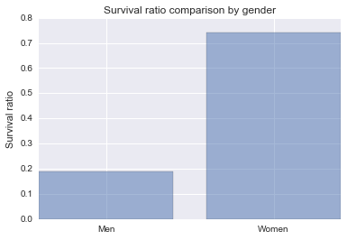

```python
men_survival=titanic_df[(titanic_df['Sex']=='male')]['Survived']
women_survival=titanic_df[(titanic_df['Sex']=='female')]['Survived']
print "Survival ratio of men: " + str(men_survival.mean())
print "Survival ratio of women: " + str(women_survival.mean())

#bar plot
y=[men_survival.mean(),women_survival.mean()]
labels=['Men','Women']
x = np.arange(len(labels))
plt.bar(x, y, align='center', alpha=0.5)
plt.xticks(x, labels)
plt.ylabel('Survival ratio')
plt.title('Survival ratio comparison by gender')
plt.show()
```

And, independent t-test is perfomerd below,

```python
def unpaired_df(a,b): #Compute Degrees of Freedom for t-test comparing means of two independent samples
    nominator=(((a.std()**2)/len(a))+((b.std()**2)/len(b)))**2
    denominator=(((a.std()**2)/len(a))**2)/(len(a)-1) + (((b.std()**2)/len(b))**2)/(len(b)-1)
    return nominator/denominator
```

```python
t, p = ttest_ind(women_survival, men_survival,equal_var=False)
print "ttest_ind: t = %g  p = %g" % (t, p)
print "df: " + str(unpaired_df(men_survival,women_survival))
```

```
ttest_ind: t = 18.6718  p = 2.2836e-61
df: 584.425953329
```

And, t-critical at alpha=.05 is about 1.97,  
Since, t-statistic > t-critical at p-value < .05, null hypothesis can be rejected.  
As a result, there is a statistically significant evidence that gender had an effect on survival. Women survival ratio is higher.

For the question 2, the hypothesis are,  
H0: Age had no effect on survival ratio in Titanic disaster.  
Ha: not H0

```
Age_Bucket
0-9       62
10-19    102
20-29    358
30-39    185
40-49    110
50-59     48
60-69     19
70+        7
Name: Survived, dtype: int64
```

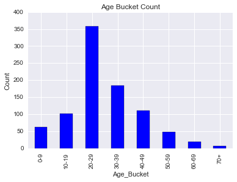

```python
#Plot of Age Bucket
age_bucket_count=titanic_df.groupby(['Age_Bucket']).count()['Survived']
print age_bucket_count
#bar plot
age_bucket_count.plot.bar()
plt.ylabel('Count')
plt.title('Age Bucket Count')
```

```
Age_Bucket
0-9      0.612903
10-19    0.401961
20-29    0.315642
30-39    0.454054
40-49    0.354545
50-59    0.416667
60-69    0.315789
70+      0.142857
Name: Survived, dtype: float64
```

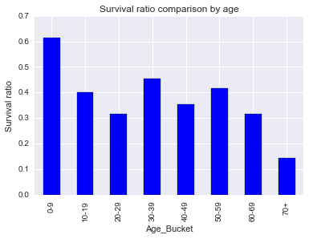

```python
age_survival_ratio=titanic_df.groupby(['Age_Bucket']).mean()['Survived']
print age_survival_ratio
#bar plot
age_survival_ratio.plot.bar()
plt.ylabel('Survival ratio')
plt.title('Survival ratio comparison by age')
```

According to above values, it looks children had more chances to survive.  
Let's look statistically as well.

```python
#df1=8, df2=883
stats.f_oneway(titanic_df[(titanic_df['Age_Bucket']=='0-9')]['Survived'],
               titanic_df[(titanic_df['Age_Bucket']=='10-19')]['Survived'],
               titanic_df[(titanic_df['Age_Bucket']=='20-29')]['Survived'],
               titanic_df[(titanic_df['Age_Bucket']=='30-39')]['Survived'],
               titanic_df[(titanic_df['Age_Bucket']=='40-49')]['Survived'],
               titanic_df[(titanic_df['Age_Bucket']=='50-59')]['Survived'],
               titanic_df[(titanic_df['Age_Bucket']=='60-69')]['Survived'],
               titanic_df[(titanic_df['Age_Bucket']=='70+')]['Survived']
              )
```

```
F_onewayResult(statistic=4.0175418808722343, pvalue=0.00024279523721014201)
```

To take a step further, Tuker HSD can be performed.

```python
mod = MultiComparison(titanic_df['Survived'], titanic_df['Age_Bucket'])
print mod.tukeyhsd()
```

```
Multiple Comparison of Means - Tukey HSD,FWER=0.05
=============================================
group1 group2 meandiff  lower   upper  reject
---------------------------------------------
 0-9   10-19  -0.2109  -0.4462  0.0244 False
 0-9   20-29  -0.2973  -0.4982 -0.0963  True
 0-9   30-39  -0.1588  -0.3733  0.0556 False
 0-9   40-49  -0.2584  -0.4904 -0.0263  True
 0-9   50-59  -0.1962  -0.4771  0.0847 False
 0-9   60-69  -0.2971  -0.6803  0.086  False
 0-9    70+    -0.47   -1.0526  0.1125 False
10-19  20-29  -0.0863  -0.2503  0.0777 False
10-19  30-39   0.0521  -0.1281  0.2323 False
10-19  40-49  -0.0474  -0.2483  0.1534 False
10-19  50-59   0.0147   -0.241  0.2705 False
10-19  60-69  -0.0862  -0.4513  0.2789 False
10-19   70+   -0.2591   -0.83   0.3118 False
20-29  30-39   0.1384   0.0061  0.2707  True
20-29  40-49   0.0389  -0.1204  0.1982 False
20-29  50-59   0.101   -0.1236  0.3256 False
20-29  60-69   0.0001  -0.3438  0.3441 False
20-29   70+   -0.1728  -0.7304  0.3848 False
30-39  40-49  -0.0995  -0.2754  0.0764 False
30-39  50-59  -0.0374  -0.2741  0.1993 False
30-39  60-69  -0.1383  -0.4903  0.2137 False
30-39   70+   -0.3112  -0.8738  0.2514 False
40-49  50-59   0.0621  -0.1906  0.3149 False
40-49  60-69  -0.0388  -0.4018  0.3242 False
40-49   70+   -0.2117  -0.7812  0.3579 False
50-59  60-69  -0.1009  -0.4969  0.2951 False
50-59   70+   -0.2738   -0.865  0.3173 False
60-69   70+   -0.1729   -0.819  0.4731 False
---------------------------------------------
```

As a result, it can be inferred that only 3 pairs of 28 had significantly different survival rates in Titanic disaster. These are "0-9 / 20-29", "0-9 / 40-49" and "20-29 / 30-39".

For the question 3, the hypothesis are,  
H0: Passenger class had no effect on survival ratio in Titanic disaster.  
Ha: not H0

```
Pclass
1    216
2    184
3    491
Name: Survived, dtype: int64
```

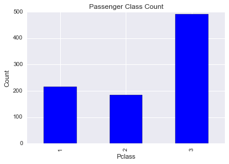

```python
#Plot of Passenger Class
pclass_count=titanic_df.groupby(['Pclass']).count()['Survived']
print pclass_count
#bar plot
pclass_count.plot.bar()
plt.ylabel('Count')
plt.title('Passenger Class Count')
```

```
Pclass
1    0.629630
2    0.472826
3    0.242363
Name: Survived, dtype: float64
```

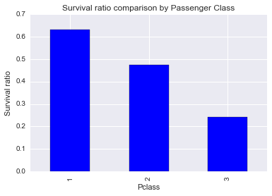

```python
pclass_survival_ratio=titanic_df.groupby(['Pclass']).mean()['Survived']
print pclass_survival_ratio
#bar plot
pclass_survival_ratio.plot.bar()
plt.ylabel('Survival ratio')
plt.title('Survival ratio comparison by Passenger Class')
```

According to above values, it looks better passenger class had more chances to survive.  
Let's look statistically as well.

```python
#df1=2, df2=889
stats.f_oneway(titanic_df[(titanic_df['Pclass']=='1')]['Survived'],
               titanic_df[(titanic_df['Pclass']=='2')]['Survived'],
               titanic_df[(titanic_df['Pclass']=='3')]['Survived'])
```

```
F_onewayResult(statistic=57.964817590910101, pvalue=2.1832474151179777e-24)
```

And, f-critical at alpha=.05 is about 2.9957, since, f-statistic > f-critical at p-value < .05, null hypothesis can be rejected. There is a statistically significant evidence at least two passenger classes had different survival chances.

To take a step further, Tuker HSD can be performed.

```python
mod2 = MultiComparison(titanic_df['Survived'], titanic_df['Pclass'])
print mod2.tukeyhsd()
```

```
Multiple Comparison of Means - Tukey HSD,FWER=0.05
=============================================
group1 group2 meandiff  lower   upper  reject
---------------------------------------------
  1      2    -0.1568  -0.2647 -0.0489  True
  1      3    -0.3873  -0.4751 -0.2994  True
  2      3    -0.2305  -0.3234 -0.1375  True
---------------------------------------------
```

As a result, it can be inferred that all pairs had significantly different survival rates. Better passenger class higher survival chance.

For question 4, some descriptive statistics can be utilized.

```python
titanic_df.groupby(['Pclass','Sex'])['Fare'].describe()
```

```
Pclass  Sex
1       female  count     94.000000
                mean     106.125798
                std       74.259988
                min       25.929200
                25%       57.244800
                50%       82.664550
                75%      134.500000
                max      512.329200
        male    count    122.000000
                mean      67.226127
                std       77.548021
                min        0.000000
                25%       27.728100
                50%       41.262500
                75%       78.459375
                max      512.329200
2       female  count     76.000000
                mean      21.970121
                std       10.891796
                min       10.500000
                25%       13.000000
                50%       22.000000
                75%       26.062500
                max       65.000000
        male    count    108.000000
                mean      19.741782
                std       14.922235
                min        0.000000
                25%       12.331250
                50%       13.000000
                75%       26.000000
                max       73.500000
3       female  count    144.000000
                mean      16.118810
                std       11.690314
                min        6.750000
                25%        7.854200
                50%       12.475000
                75%       20.221875
                max       69.550000
        male    count    347.000000
                mean      12.661633
                std       11.681696
                min        0.000000
                25%        7.750000
                50%        7.925000
                75%       10.008300
                max       69.550000
dtype: float64
```

```
(0, 260)
```

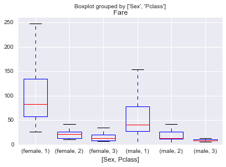

```python
titanic_df.boxplot(column='Fare',by=['Sex','Pclass'], widths=0.7)
plt.ylim((0,260))
```

For the question 5, the hypothesis are,  
H0: Passenger class had no effect on abroad relative number.  
Ha: not H0

```
Mean relative number of Class 1: 0.773148148148
Mean relative number of Class 2: 0.782608695652
Mean relative number of Class 3: 1.00814663951
```

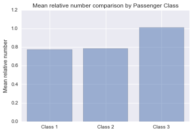

```python
class1_relative=titanic_df[(titanic_df['Pclass']=='1')]['SibSp_Parch_sum']
class2_relative=titanic_df[(titanic_df['Pclass']=='2')]['SibSp_Parch_sum']
class3_relative=titanic_df[(titanic_df['Pclass']=='3')]['SibSp_Parch_sum']
print "Mean relative number of Class 1: " + str(class1_relative.mean())
print "Mean relative number of Class 2: " + str(class2_relative.mean())
print "Mean relative number of Class 3: " + str(class3_relative.mean())

#bar plot
y=[class1_relative.mean(),class2_relative.mean(),class3_relative.mean()]
labels=['Class 1','Class 2','Class 3']
x = np.arange(len(labels))
plt.bar(x, y, align='center', alpha=0.5)
plt.xticks(x, labels)
plt.ylabel('Mean relative number')
plt.title('Mean relative number comparison by Passenger Class')
plt.show()
```

According to above values, it looks third class may have more relatives.  
Let's look statistically as well.

```python
#df1=2, df2=888
stats.f_oneway(titanic_df[(titanic_df['Pclass']=='1')]['SibSp_Parch_sum'],
               titanic_df[(titanic_df['Pclass']=='2')]['SibSp_Parch_sum'],
               titanic_df[(titanic_df['Pclass']=='3')]['SibSp_Parch_sum'])
```

```
F_onewayResult(statistic=2.2603199692962921, pvalue=0.10491697132973478)
```

So, f-critical at alpha=.05 is about 2.9957, since, f-statistic < f-critical at p-value > .05, null hypothesis can be failed to reject. There is no statistically significant evidence that at least two passenger classes had different abroad relative number.

For the question 6, the hypothesis are,  
H0: Abroad relative number had no effect on survival ratio.  
Ha: not H0

```
Relative_Bucket
More Than One Relative    0.466321
No Relative               0.303538
One Relative              0.552795
Name: Survived, dtype: float64
```

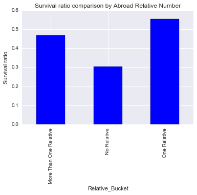

```python
relative_survival_ratio=titanic_df.groupby(['Relative_Bucket']).mean()['Survived']
print relative_survival_ratio
#bar plot
relative_survival_ratio.plot.bar()
plt.ylabel('Survival ratio')
plt.title('Survival ratio comparison by Abroad Relative Number')
```

According to above values, it looks abroad relative number may have some effect on survival. Let's look statistically as well.

```python
#df1=2, df2=889
stats.f_oneway(titanic_df[(titanic_df['Relative_Bucket']=='No Relative')]['Survived'],
               titanic_df[(titanic_df['Relative_Bucket']=='One Relative')]['Survived'],
               titanic_df[(titanic_df['Relative_Bucket']=='More Than One Relative')]['Survived'])
```

```
F_onewayResult(statistic=20.665027805882485, pvalue=1.6899909134170302e-09)
```

So, f-critical at alpha=.05 is about 2.9957, since, f-statistic > f-critical at p-value < .05, null hypothesis can be rejected. There is a statistically significant evidence that at least two relative buckets had effect on survival.

To take a step further, Tuker HSD can be performed.

```python
mod3 = MultiComparison(titanic_df['Survived'], titanic_df['Relative_Bucket'])
print mod3.tukeyhsd()
```

```
        Multiple Comparison of Means - Tukey HSD,FWER=0.05
==================================================================
        group1            group2    meandiff  lower  upper  reject
------------------------------------------------------------------
More Than One Relative No Relative  -0.1628  -0.2566 -0.069  True
More Than One Relative One Relative  0.0865  -0.0329 0.2058 False
     No Relative       One Relative  0.2493   0.1488 0.3497  True
------------------------------------------------------------------
```

As a result, it can be inferred that having at least one relative had statistically significant effect on survival. If a passenger had at least one relative also had higher survival chance.